# New Heading

### Contact information

Archives, California Institute of Technology  
Mail Code 015A-74  
Pasadena, CA 91125  
Phone: (626)395-2704 Fax: (626)793-8756  
Email: archives@caltech.edu

Graphics and content © California Institute of Technology.

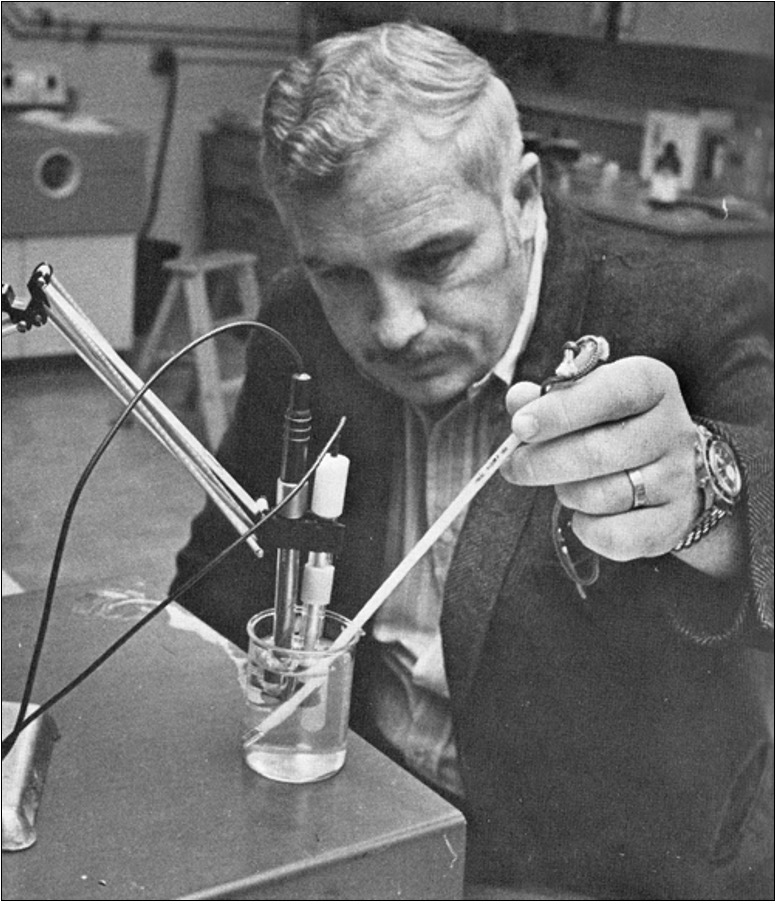

> James Morgan tests the waters in 1970, the year Caltech started a degree program in environmental engineering science. His work on water quality and wastewater treatment would later win him the Stockholm Water Prize and the Clarke Prize (both 1999).

**California Institute of Technology**

**Oral History Project**

**Interview with James J. Morgan**

**by Shirley K. Cohen**

**Pasadena, California**

**Caltech Archives, 2001**

**Copyright © 2001 by the California Institute of Technology**

**JAMES J. MORGAN**

**TABLE OF CONTENTS**

*Session 1:*

pp. 1-10

Upbringing in Ireland and New York, during the Depression. Family background. Parochial schooling. Studied civil engineering at Manhattan College, 1950s. Growing interest in water purification. Early 1960s and beginnings of public environmental consciousness.

> pp. 10-19

Graduate work at Univ. of Michigan. MS in environmental health engineering, with C. J. Velz, 1956. Instructor of civil engineering at Univ. of Illinois; takes chemistry courses there. Three years at Harvard with W. Stumm; PhD 1964. Recollections of Stumm. Joint appt. in chemistry and engineering at Univ. of Florida 1963-1965.

> pp. 20-29

Offered job at Caltech, 1965; recommended to J. McKee by G. M. Fair, S. Friedlander, and W. Stumm. Gives seminar at Caltech January 1965; arrives for good in September. To W. M. Keck Eng. Lab. Relationship with J. McKee. McKee builds environmental health engineering dept., hiring W. North, S. Friedlander, and Morgan. 1970, new degree program in environmental engineering science. Relationship to civil engineering faculty.

*Session 2:*

> pp. 30-39

Recollections of D. O’Connor, Manhattan College. Admin. duties at Caltech: Freshman Admissions Committee 1969-72; dean of students 1972-75; EO for env. engineering sci. 1974-1980; v.p. for student affairs 1980-1989. Ed. *Environmental Science and Technology* 1966-74. Recollections of L. DuBridge.

> pp. 40-48

Balancing teaching and research with admin. duties. Comments on job of v.p. for student affairs. His love of teaching.

> pp. 49-58

Chairs faculty 1977-79. Service on search committee for new president after departure of H. Brown. Interaction with trustees as v.p. for student affairs. Instrumental in getting Braun Gym built. Fosters contact between trustees and undergraduates.

*Session 3:*

> pp. 59-67

Recollections of being on TV quiz show in high school; his interest in history. Recollections of consulting at Caltech. Work on ACS committee on environment, 1967-1969. Work on NRC panels. Consultant for Procter & Gamble, LADWP, So. Cal. Coastal Water Research Project.

> pp. 68-77

Work on textbook, *Aquatic Chemistry,* with W. Stumm. Summer in Woods Hole, 1974. Comments on PhD students F. Morel, J. Pankow, A. Stone, H. Liljestrand, Y. Erel. Hopes to go to Israel.

> pp. 77-95

1999 Stockholm Water Prize, to be shared with W. Stumm. Comments on earlier awards and his career at Manhattan College. Teacher award (1959) from Danforth Foundation. Certificate of merit from ACS (1961). Paper on “Chemical Aspects of Coagulation,” multiple awards. Nalco award for his student W. Sung. S. Freese award. History of Stockholm Water Prize. Membership in Assoc. of Env. & Eng. Sci. Professors and lectureship. Repeats as EO for env. science 1993-96. General comments on Caltech and his plans for the future.

*Epilogue:*

pp. 96-98

James Morgan’s Account of Receiving the Stockholm Water Prize and the Clarke Prize

CALIFORNIA INSTITUTE OF TECHNOLOGY

ORAL HISTORY PROJECT

Interview with James J. Morgan By Shirley K. Cohen

Pasadena, California

> Session 1: May 25, 1999

Session 2: June 1, 1999

Session 3: June 16, 1999

Begin Tape 1, Side 1

Cohen: Good morning, Dr. Morgan. Good of you to come and have this interview with us. Perhaps we could start with your telling us about your family background: your parents, what they did.

Morgan: I am the first child of Irish immigrant parents. My father and mother were married in 1927 and came to New York the next day. I was born in 1932 in New York. A year later my parents went back to Ireland, where they owned a farm, and I was raised there.

Cohen: Why did they do that?

Morgan: The Depression.

Cohen: Oh!

Morgan: I often say it was hard to figure out where it was easiest to starve most graciously. So they had the farm, and they went back to it and stayed there for about—oh, I guess it must have been four and a half years. And then we came back. I had the occasion to go back for the first time, just ten years ago, to see it, and it was a very poor-looking farm. I guess most of the farms are, in that part of Ireland—which is the county of Monaghan, one of the border counties in the northern part of Ireland. It’s very, very poor land, so it must have been a very scrappy existence. I only remember the pleasant part—being a kid on a farm and having a dog and things of that sort.

Cohen: So you had an extended family there? You had grandparents, aunts, and uncles?

Morgan: Grandparents, aunts, and uncles, that’s right. And I still do have at least a dozen first cousins living in that small ten-square-mile area of Ireland. Anyway, the family came back about half a year before I started first grade. So I started first grade in a parochial Catholic school in the Bronx. And then after about three and a half years we moved to a different part of New York—Washington Heights, on the Upper West Side. In the fourth grade, I went to P. S. 189, whose song had the immortal lines “Enthroned between two rivers bright, our schoolhouse nobly lies.”

Cohen: Oh, that’s nice.

Morgan: Those turned out to be the Harlem River and the Hudson River. [Laughter] I finished public grammar school.

Cohen: What did your father do?

Morgan: My father had many different jobs over time. Actually, he came to the United States first in 1922, before he was married, and he was a motorman on the trolleys. And then when he came back, after he and my mother were married, I think he did that again for a while. Then when we all came back in 1937 or so, the Depression in fact was worse. I remember that one of his first jobs was as a construction worker on the new Independent subway—which I grew up calling the Sixth Avenue subway—and that was his job for quite some time. Then by the time I was in about the fourth grade and can remember such things, he divided his time between being a building superintendent and a plumber. And I remember still with great pleasure that when I was about fourteen he actually taught me plumbing. I knew how to thread pipes and do elbows and joints and things of that sort.

Cohen: I see. So your interest in water started early. [Laughter]

Morgan: I didn’t know it was an interest in water. And occasionally he would divert to being a high school custodian. I remember that he was custodian at Evander Childs High School, up in the Bronx, which I’ve never seen.

I have a younger sister who was born in Ireland. She’s about four years my junior. She still lives in the New York area, out in Bay Shore. And as is often the case, we are now very, very close. When we were young, we couldn’t stand the sight of one another. She’s one of my best friends now. It’s a very happy thing to say.

Cohen: Oh, that’s nice!

Morgan: My mother passed away at the age of seventy-seven. My father passed away in Ireland. He went back to Ireland after he retired in New York. He passed away at the age of seventy-three.

Cohen: So you mean that after they were done working, they went back to Ireland?

Morgan: No. He went back to find them a place to live.

Cohen: Would you say that their attachment was never very strong to this country?

Morgan: Never, [except] in the following sense: I think their attachment was strong because they could see that it was where their children were going to have a better life. I often admire my father when I think about the perils [he faced]. He crossed the ocean five times in order to find a place to settle down and have a job and raise a family; my romanticization of that is that it was a very pioneering sort of thing to do. So they were very attached to Ireland all the time that they lived in New York.

Cohen: Did they become citizens?

Morgan: My father did fairly early on. My mother never did. She didn’t see the need for it as long as my father was a citizen. So when my father went back, in 1968, the idea was to find a place to live, because they had long since deeded over the farm to one of his relatives many, many years before. And while he was over there, he contracted bronchial pneumonia and passed away in a matter of just two and a half months. My mother was living with us in California temporarily at the time. In fact, we were in San Diego that summer—the summer of 1968.

So they had an attachment to Ireland which was very, very strong. Almost all the friends of the family in the West Side neighborhood in which I grew up were Irish people—not only Irish people but from the same part of Ireland back home.

Cohen: So it was like a little colony over here.

Morgan: But fortunately for me, I grew up as a typical New York kid—especially after I started to go to public school, which was just an accident. I would have gone to parochial school probably all the way through if it weren’t for the fact that I had whooping cough when I was very young and lost a whole half year in parochial school. So when we moved to the West Side, Washington Heights, my mother tried to enroll me in the local parochial school, and they said, “Well, we’ll have to leave him back six months, because we only work on a twelve-month calendar.” So she refused and put me into the public school, which was the best thing that ever happened to me, personally, because now I met Armenians, Greeks, Jews, Italians, Germans, all sorts of different people. Personally, it changed my whole view of life. Although when I was through with public school I went to a Catholic high school—one of the large melting-pot Catholic high schools, which is still very, very successful at moving people up the social ladder. That’s their mission. Cardinal Hayes High School, over on the Grand Concourse. I went there, and then I went to a Catholic college. But it had nothing to do with religion at that point; it had to do with who would give me a scholarship. So I went to Manhattan College, which is a smallish school with an engineering program and a business program and a liberal arts and science program. They gave me a scholarship, and I had a New York State Regents scholarship. So I actually, believe it or not, made a little money going to college for four years.

And then, after that, I left New York, never really to return. I was not as attached to New York as—

Cohen: So you got a good education—between the high school and—

Morgan: I did. I was fortunate in that the high school gave me a very solid grounding in mathematics and science. One of life’s little ironies, though, is that because of some sort of counseling mistake, even though I went to a Catholic high school—and everybody knows that if you go to a Catholic high school, you’ve studied Latin—I never studied Latin. I never studied French. I never studied German. And when I came to the guidance counselor to be certified for graduation, I remember him saying, “There’s something terribly wrong here.” [Laughter] And I said, “What’s that?” He said, “You’ve never studied a language.” And I could honestly say, “Nobody ever told me to.” Now, there was nothing to be done about it, because I graduated in the top twenty of a class of 750.

Cohen: I was going to say that you probably were a good student.

Morgan: I was a successful student. My first love was history, actually.

Cohen: Is that right?

Morgan: And if I had won the scholarship that I was hoping to win to Fordham University—another Catholic university, as it turns out—I would have gone there, because they had a special program which would allow people to catch up if they had somehow not studied languages in high school. And that was my first love—American history. But no scholarship, no Fordham. So I went to Manhattan. I was also admitted to Columbia.

Cohen: But that would have been expensive?

Morgan: Well, it would have been free, if I had won the NROTC scholarship. I passed the academic part and then, ironically, failed the physical. All my life I’ve had what’s called excessive curvature of the spine. I still have it. And it’s the cause of pretty much lifelong back pain, which is a little bit hazardous for somebody who still plays basketball and tennis.

Anyway, that’s the story of how I ended up at Manhattan, and that brings me to the end of my New York life.

Cohen: So then you finished college?

Morgan: I finished college and went to the University of Michigan.

Cohen: And what was your major [at Manhattan]?

Morgan: Civil engineering. In the fifties, when I entered college, it was the same year that the Korean War started. I received my induction notice in August of 1950, and I was advised by the college—since I was already admitted and would soon be enrolled—to simply tell my draft board that I was about to be enrolled in an engineering program. And everybody in that freshman class who was in engineering received an automatic deferment. And almost everybody that I can remember from my high school who was studying liberal arts was drafted. It gave me a very strange outlook on life, which had to do with probabilities and being lucky or being unlucky. And then two years later, many of those people who had been drafted came back and resumed. They were only in the service for two years. They came back in 1953 and picked up college where they had left off.

Cohen: And of course they had the GI Bill.

Morgan: That’s right.

Cohen: Wasn’t that extended to the Korean War veterans?

Morgan: Yes. So civil engineering was the thing that attracted me most, once I was enrolled in engineering. But the irony, again, has to do with that little mistake of not having studied language. Because after my first year in engineering, in which I did very well, I tried to transfer to the School of Arts and Sciences at Manhattan College.

Cohen: You still wanted to do history?

Morgan: And they wouldn’t let me.

Cohen: Because of the language?

Morgan: Same deal. But by this time I was starting to find my feet in engineering. That is, I started to see things that were appealing. Civil engineering was appealing to me. And it was in my junior year that I really saw the social side of engineering. I became interested in water and water purification and some of those aspects.

Cohen: When did the word “environmental” come into being?

Morgan: That’s interesting. If you trace the word “environmental” back to Caltech, which is a later part of the story, Jack McKee used it for the first time in 1960, when the faculty started a new degree program called environmental health engineering.

Cohen: Right. And we will talk about that.

Morgan: Early on, the part of civil engineering that I started to pursue was called, depending on the university you were in, either public-health engineering—which is what it was called at the University of Michigan, where I did my master’s degree—or sanitary engineering.

Cohen: So it was environmentally focused.

Morgan: Oh, yes. But the problems were what I call the classical twentieth-century problems, which are the prevention of disease through proper water treatment and the prevention of water pollution through proper waste treatment. In other words, sanitation for human health protection and sanitation to protect natural waters. And that’s what I saw as—

Cohen: It connected you to society in some way.

Morgan: Yes. Part of the disappointment for my father was that he could see that I was never going to be interested in making money. And, of course, one of the things that excited him about my going into engineering was that (a) it validated my education, and (b) he thought, “Well, this son of mine will make a good living.” Well, in the long run I made a good living, but I never was attracted to what I would call the business side, or the professional engineering side. I took the first examination for my license and passed it, but I really got more and more attracted, as I went on into my twenties and early thirties, to the applied-science side of it.

Cohen: So you enjoyed your math and your science and your chemistry, and things like that.

Morgan: Well, there’s a great irony about the chemistry, because chemistry was the course that I disliked most intensely in my freshman year at college.

Cohen: Is that right?

Morgan: Because it was taught in a way that I can only describe as militaristic. In fact, we used to joke—and it wasn’t a very good joke—that the man who ran the chemistry laboratory for all freshman must have escaped from Nazi Germany, because he had such a militaristic style. So I left freshman chemistry thinking, “Whew! Boy, I’m glad I’ll never have to do anything like that again!” I was wrong. [Laughter] But it took me several years to find out.

Anyway, the environment—other than in the sense of water supply and treatment—started to become a national issue in, I would say, the late fifties. And that’s when chemical pollution started to be recognized. And it was in 1962 that Rachel Carson wrote her famous book, *Silent Spring*. Public consciousness of the environment in a broader sense, in my experience, dates to about 1957, 1958. And then Rachel Carson’s book in 1962.

Cohen: That’s quite interesting. Because I’m thinking, having just seen this Pauling exhibit and the to-do they made about the atomic bomb—that didn’t enter into health consciousness?

Morgan: Oh, it did in the following way. In 1958, when I went to visit Harvard for the first time—because by that time I was starting to think of graduate school in a full-time way—one of the things I noticed was that there were these collectors scattered around the Harvard campus. So I asked one of the people [and got the response,] “Oh, those are the rainwater and fallout collectors of Professor [Harold A.] Thomas [Jr.]. He’s studying the contamination of water from bomb fallout.” So the AEC [Atomic Energy Commission], at a number of universities in the late fifties and well on into the sixties, but certainly for the first time in the fifties, was very, very interested in knowing where the bomb fallout went. And of course bomb testing was going on in the Pacific, as you remember. And the jet stream was carrying it across the Northern Hemisphere and dropping it across the United States, and then on over into Europe, and so forth. Apparently, one of the jokes at Harvard—Harvard students having some of the eccentricities that Caltech students are famous for—was that the only difficulty with these samplers was how to keep the Harvard students from urinating in them. They thought that would be a great thing to do. [Laughter]

Cohen: You know, the silence about this may have had something to do with national security. They didn’t want any protests to stop them from testing.

Morgan: I guess so, yes. But that was an era in which, I think, Rachel Carson’s book—and a few things maybe less dramatic than that—made the environment a much more general issue than it had been before. When I started to become aware of it, as an undergraduate, it was really [only] a professional issue. You got a bachelor’s degree, or maybe a master’s degree, and you were qualified to work in a consulting engineering firm, a state health department, possibly with the United States Public Health Service, or possibly you went to other countries—before there was a Peace Corps—and did things like AID [Agency for International Development] work and so forth. And what happened with the advent of chemical pollution as a recognized fact is that more and more people became interested in it. People who didn’t start out with any professional connection to the environment at all suddenly took a very strong interest in it and became very, very well recognized. One of the great public figures in the sixties was Barry Commoner.

Cohen: OK. I do remember his books.

Morgan: And one of the things that he did was to use student dental samples in order to trace the fallout and the accumulation of strontium in the human body [in] bones and teeth.

Cohen: Is that right? How interesting.

Morgan: And he did that in [Washington University in] Saint Louis. His original career was microbiology. Sheldon Friedlander, who was at Caltech for many years and was a good colleague and friend, used to joke that the modern sanitary engineers would be people like Barry Commoner. Partly Sheldon was joking because he didn’t like that, and partly he was joking because he could see the truth in it—which was that science of a much wider scope was going to be important. It wasn’t going to be a matter of a little, close community of people who did environmental work; it was going to become larger and larger. And Sheldon himself was a chemical engineer. He was one of the people who actually attracted me to Caltech.

Cohen: Is that right?

Morgan: Yes.

Cohen: OK. Well, let’s do your graduate work first.

Morgan: Well, I finished my master’s degree at the University of Michigan [1956], where I also met my wife. We both received our master’s degrees there; then we were married in Ann Arbor and I moved to the University of Illinois.

Cohen: And what was your master’s degree in?

Morgan: It was in environmental health engineering—what was then called public-health engineering.

Cohen: I see. OK. So already it was distinguishable as a field.

Morgan: Yes, that’s right. There were two places you could study it at the University of Michigan, and I studied it in both—that is, I was a hybrid student. I worked in the School of Public Health as a research assistant, and I took courses in the medical school and also in civil engineering. Down on the main campus in civil engineering, it was called sanitary engineering; and up on the hill in Public Health it was called public-health engineering.

Interestingly enough, there’s a long tradition in the United States of environmental protection going through schools of public health. Columbia was very, very famous in the twenties and thirties for its work on stream sanitation. And there was a great faculty member there named Earle B. Phelps who had a protégé named Clarence J. Velz, who was the man I eventually worked with for my master’s degree at the University of Michigan. So they came to a concern about water from a public-health perspective. In other words, the survival of harmful organisms in the water was one of their interests. Disinfection was another one of their interests. So there were various threads that were separate through most of the twentieth century that now, in our time, are more or less all together.

Then I went to Illinois to teach. After having a master’s degree, I liked to tell my students that I thought I knew everything there was to know.

Cohen: You still hadn’t taken any languages?

Morgan: Actually, yes. I spent two years getting my master’s degree at Michigan, because I worked half-time in the School of Public Health as a research assistant and the rest of the time I took courses at a half-time rate, so it took me two years to get a master’s degree. And in that time I took my first language course. It was a German course, and it was called German Reading for Scientists and Engineers. That was my first formal contact with [a foreign] language, and I found out that I enjoyed it—although German was probably the most difficult thing for me to start with. I probably would have found it easier to start with French. But I was told by somebody that if you want to get a PhD, you’re going to need to know how to read German and maybe another language. And the choices then tended to be usually French and German, then later Russian. So after these two years at Michigan, in which I studied a variety of mathematics and chemistry and microbiology, I took my first advanced mathematics courses. Because in civil engineering in the fifties, you essentially took two years of calculus, and that was it—unlike Caltech, which even in the forties and fifties was setting the standard for mathematics as a foundation for all of its scientists and engineers.

Cohen: But how about physics? Didn’t you take physics?

Morgan: Oh, yes. I took two years of physics.

Cohen: The calculus was enough mathematics for the physics they did?

Morgan: Yes, it was, but it wouldn’t have been enough for the graduate level. So when I went to the University of Michigan, one of the first courses I took was differential equations, which would have been the next [level of course work].

I went to Illinois because I saw a journal on the library shelf called the *Journal of Engineering Education,* put out by the American Society for Engineering Education. And I saw that it was published on the campus of the University of Illinois. So, completely on a lark, I wrote to the editor and said, “If your journal ever learns about teaching opportunities.…” And I wasn’t thinking of Illinois in particular, I was just thinking of engineering education opportunities, because I had no real idea about how you did such things. So apparently this editor walked down the hall to the chairman of the civil engineering department and said, “Here’s somebody who’s interested in a teaching job.” And sight unseen, they hired me. I never even went down for a visit. I took a job as an instructor; I was called an instructor of civil engineering, and one of the privileges of being an instructor in those days was that you could begin to work on your PhD part-time.

Cohen: Whose stuff you’re interested in?

Morgan: Whose stuff you’re interested in, and who can really be—the European expression is a “doctor father.” The environmental faculty at Illinois was then in a state of intense transition, and there were really no senior leaders. The year I arrived, three people retired or resigned from the faculty. [Laughter] So after three years, my wife and I talked about it. We applied to various schools.

Cohen: Was your wife in public health also?

Morgan: No. She’s an elementary schoolteacher.

Cohen: Oh, OK.

Morgan: So after a lot of thought, we applied to Johns Hopkins, Harvard, and Berkeley. We didn’t apply to Caltech. Although my wife’s a Michigan person, before I met her she had spent a year teaching in Long Beach, California, as an elementary schoolteacher. And she said, “We wouldn’t want to live in California. It’s so smoggy out there.” Accurate in the 1950s.

Cohen: Yes.

Morgan: So we went to Harvard, to make a long story short. And that was a great success, because I knew who I wanted to work with. It was Professor Werner Stumm, who later invited me to coauthor *Aquatic Chemistry*. I only spent three years at Harvard, taking a few courses, doing my research, and then took a faculty position at the University of Florida.

Cohen: Now, just backing up a minute, I know from Shel Friedlander that his mentor at Harvard was actually Molly Scudder’s father, the man who invented the iron lung.

Morgan: That’s right. [Philip] Drinker.

Cohen: Did you have anything to do with that?

Morgan: No. Harvard had two completely different environmental worlds, geographically separated. The School of Public Health was in downtown Boston, and the program that I was in was in the Division of Engineering and Applied Physics, which is a very rough analog of our Division of Engineering and Applied Science here. So I took all my courses in Cambridge or—actually, I took one course down at Woods Hole, in oceanography. We went down once a month and had a series of lectures and we did some field work. That was for my minor, which was marine biology.

So we were only three years at Harvard. I wrote a draft of my thesis. I took the teaching job at the University of Florida. I wrote a second draft after we had been in Florida for a few months. And then I came back and defended—I think it was April. So although I was in residence at Harvard only three years, it was one of the most intense learning experiences of my life. I developed a collegial and friendly relationship with Werner Stumm, so that when he passed away this past spring, I had known him for thirty-nine years.

Cohen: That’s a long time.

Morgan: A teacher, colleague, and friend. And he was the person I’d been looking for—the person who would be my mentor. And I had the great good fortune to be his first PhD student.

Cohen: Now, he was Swiss?

Morgan: That’s right, he was educated in Switzerland. He was, by early education, a PhD in inorganic chemistry. He worked with one of the very well-known Swiss inorganic chemists of the time, Gerold Schwarzenbach. And by sheer chance, he discovered the environment not as a graduate student but when he was looking for his first job after finishing his PhD. Jobs were tight at the time. Apparently what you did if you got a PhD in Switzerland was you went to work for the Swiss chemical industry. Werner had some sense that he didn’t want to work in industry, but in any event the market wasn’t all that great. There was a job at one of the federal laboratories, which happened to be located in Zurich no more than a block away from where he had gotten his PhD at the University of Zurich. It was part of the ETH [Eidgenössische Technische Hochschule], the Swiss federal technical school, and it was a job as a water chemist—that is, doing water analysis and designing measurement programs. He took it and he discovered water chemistry. He had never even thought about water chemistry.

Cohen: These things are often serendipitous.

Morgan: Yes. So after two years of doing that, he thought, Well, there must be more known about this than I can see. So he made some inquiries, he read the literature, and he found out that Harvard—this was in 1953—actually had an educational and research program in what was then called sanitary engineering and did a lot of work on water treatment, disinfection, and things of that sort. They had the leading program on the East Coast. And I would say that Berkeley, at that time, had the leading program on the West Coast. So he applied for a postdoctoral fellowship and so did his wife, who was a PhD geneticist. They each got $1,000 as a stipend—period. And they packed up and went to Harvard. Now, one of life’s little ironies is that if I had gone to Harvard right out of Manhattan College, I would have been a first-year graduate student when Werner Stumm was a postdoc. But I went to Michigan, and then from Michigan to Illinois, and then I finally came to Harvard. And when I came to Harvard, he was just up for tenure that year, and he received it. And his philosophy had been “I take no graduate students until I have tenure,” because Harvard was notorious, in his view, for very seldom granting tenure. He thought it was just too risky for a student, and for him. So I arrived at just the time that he was in the tenure process. The following spring, he received tenure, and he said, “Do you want to be my graduate student?”

Cohen: Ah, so you were first.

Morgan: I said, “And how!” [Laughter] So that’s how that happened. He was a pure chemist by background. He discovered the environment through his first real full-time job. And what he learned was that many of the ways that things were being done were not all that imaginative and not all that chemically sound. So he, sort of on his own, discovered some things. Then he went to Harvard. And the man that he was going to work with, Edward Moore, without telling him, had already planned to be on sabbatical that year. So Werner Stumm went to Harvard and worked alone for twelve months. They gave him a little corner of the laboratory. He didn’t speak very much English. He learned how to write on his own. And at the end of the year, he wrote a paper and showed it to Moore, who had come back from sabbatical at about that time. And Moore said, “This is tremendous. How did you do this?” It was on calcium carbonate inhibition of corrosion of metals, which was water pipes. It was a chemical attack of a sort that never had been done before. And Moore said, “You should publish this. You should send this straight away to the leading journal in the field,” which at that time was the *Journal of the American Waterworks Association*. And Werner, thinking it was the polite thing to do, offered to have Moore as a coauthor. And Moore honestly said, “I have nothing to do with this. This is your work. Submit it.” It’s one of the really classic papers.

Cohen: Is that right?

Morgan: And he did it all on his own. Anyway, Harvard had the good sense a year later to invite him back.

Cohen: To keep him there?

Morgan: No, he went back to Switzerland. But a year later they had a search for a young faculty member in what was then called sanitary chemistry, and they hired him in 1956. When I arrived at Harvard, four years later, he was just coming up for tenure, as I said—which was very early at Harvard, because Harvard usually takes about eight to ten years to make a tenure decision. So that means—now that I look back—that he must have been sensational.

Cohen: Well, he was a real pioneer, too.

Morgan: I just knew that he was a brilliant teacher. I took his course when I arrived, and he had a way of teaching that was entirely original, very imaginative; he had flair. I learned how he wrote. One day I came into his office when he was working on a paper. He had a desk near the window, a big desk. There were about a dozen books spread out, opened to different pages. They were all examples of good scientific writing. And he was—

Cohen: Plagiarizing? [Laughter]

Morgan: No, he wasn’t plagiarizing; he was learning words. He didn’t have a vocabulary. So he would have a word in German, and then he would try to find the corresponding word. So as a result, some of his early papers tend to have some unusual sort of self-invented clichés in them.

Cohen: [Laughter] What fun!

Morgan: Which were his adaptations of classical chemical textbooks and journal articles and so forth. I thought, “How would I do it, if I had to learn?”

Cohen: That’s certainly a good way to do it.

Morgan: He just taught himself.

Cohen: It sounds like he had a lot of gray matter.

Morgan: Yes. Very original. Very original.

Cohen: So you were there with him for three years?

Morgan: Three years.

Cohen: And evidently you established a really fast, firm friendship, aside from everything else.

Morgan: That’s right. And I took the job at Florida because (a) it was the only job that was available to do water chemistry, as I now saw myself—

Cohen: So you called yourself a water chemist.

Morgan: I now saw myself as a civil engineer turned water chemist. One of my close friends at the University of North Carolina, a man very senior to me, often refers to me as an engineer gone wrong. When Werner and I received the Stockholm Water Prize announcement, Dan Okun sent me a very nice letter saying, “You haven’t done so badly for an engineer gone wrong.” [Laughter]

Cohen: Oh, how nice! So you lived where in Florida?

Morgan: Gainesville. The University of Florida at Gainesville. We were there for two years. It was pretty clear we didn’t want to stay.

Cohen: Oh, it’s very different from Cambridge.

Morgan: It was very different. It was a very backwater area, although the university was a good university. And I was in the chemistry department there. That is, my labs and my office were in the chemistry department. And I had a joint appointment between chemistry and environmental engineering. It was now called environmental engineering at the University of Florida already.

Cohen: Oh, OK. So we’re in the early sixties?

Morgan: 1963.

Cohen: So the word “environmental” is creeping into the language.

Morgan: Yes. And Jack [McKee], as I said before, had already used it for the name of the new program here in 1960. Keck [W. M. Keck Engineering Laboratories] was to be part environmental health engineering, [part] water resources engineering, and [part] material science, which it still is to this day.

My wife and I had a sense that we didn’t want to stay [in Florida] because she couldn’t stand the bugs, I couldn’t stand the humidity, and together we couldn’t stand the culture of Gainesville. But I wasn’t looking for a job. It’s been my habit that good things happen to me—that if you do good work, your work gets heard about. So it was the following very, very unusual set of circumstances: In 1965 I came to Caltech. And in the year leading up to that, Caltech had decided they wanted to hire a young water chemist. Apparently, recommendations about me came from three quite unusual sources, in the words of Jack McKee, because he couldn’t imagine that these three different people could all agree on one person, or on anything! And those three people were Gordon M. Fair, who was the great man of sanitary environmental engineering at Harvard—

Cohen: Fair?

Morgan: South African, I think, originally. I think he was probably a student or a colleague of Drinker’s, because he had an appointment both in engineering and in public health. And the second was Werner Stumm. Jack had already met Werner Stumm and knew that he was eccentric and, from Jack’s point of view, probably slightly insane, being a Swiss. And then the third was Sheldon Friedlander. And how I came to meet Sheldon was that at the very tender age of thirty-two I got appointed to a National Institute of Environmental Health Sciences review panel for reviewing research grants. I still don’t know to this day how that happened, but somebody must have put my name into the hopper. And they needed somebody who was water-quality oriented and so forth. That was a multidisciplinary panel; it had about a dozen people. It covered air pollution, biology, water pollution, and industrial health. And who else was on the panel but Sheldon Friedlander—he had just come to Caltech, in 1964.

Cohen: He was at Johns Hopkins before that?

Morgan: Yes, he had just come to Caltech. And he went back and told Jack McKee, “That’s the guy you’ve got to hire.” [Laughter] So that’s why Jack told me later, with some amusement, that it was the strangest set of circumstances, because he couldn’t imagine—

Cohen: Three people like that agreeing on anything.

Morgan: Right.

Cohen: Well, maybe if they’d known the others were of the same mind, they might not have.

Morgan: To make a long story short, they invited me out, I gave a seminar, they offered me a job, and then I almost blew it. I was so busy at Florida trying to help teach in the program, and I had already taken on helping finish a graduate student, and Fred Lindvall [professor of electrical and mechanical engineering], who was the chairman of the engineering division, wrote me a letter offering me the job—an untenured faculty position in the division at such-and-such a salary. And I said, “Gee, that’s nice.” And apparently, in my typical preoccupied [mode], I put it aside. And three weeks later, Jack McKee called and said, “Did you receive our letter?” And I said, “Yes, I did.” And then he said, “And ?” And I said, not thinking, “Well, I’m thinking about it.” And Jack said, “Thinking about it?” [Laughter] And then he said, “If you’re thinking about it, I’m not so sure that you’re our man.” So I said—I didn’t call him Jack McKee—I said, “Professor McKee, I accept. I’ll send a letter tomorrow.” And I did.

Cohen: And your wife didn’t mind going back to California? Maybe after Florida, anything is all right.

Morgan: By this time, California looked good. In fact, Jean wouldn’t think of leaving California. We’ve lived here for thirty-five years now.

Cohen: Yes.

Morgan: Furthermore, the air, for whatever reason, has gotten better.

Cohen: It has gotten better, yes.

Morgan: So that’s how I arrived at Caltech, through that circuitous pathway.

Cohen: Well, you had visited, because you had given a seminar here.

Morgan: I gave a seminar in January of 1965.

Cohen: You were coming from Florida, so it didn’t matter, but January is the month when you see the flowers blooming.

Morgan: It was entirely accidental, because I was going to one of these NIEH study-section meetings, which was held on the [University of California at] Riverside campus. So they said, “As long as you’re in Riverside, why don’t you come over?” So I came over to Caltech and gave a seminar. I remember that I gave the seminar in the same room we use to this day: 142 Keck. And I remember what I talked about. And for some reason the room was absolutely packed and people were literally sitting in the aisles on those little steps that they had in those days in 142 Keck. And all I remember is that I was on a fifty-minute high. I just talked and talked and talked. It turns out I was talking about new approaches to treating water using synthetic polymers, polyelectrolytes, which were becoming available at the time. It was the main research that I was doing with my doctoral student at Florida. And afterward I remember people coming up and asking me questions and saying, “Boy, this is really exciting work!” I was really on a high. And then I went back to Florida. [Laughter] That was January. And then the job offer came about six weeks later.

Cohen: And so you went the following fall? You moved to California?

Morgan: We arrived September 1<sup>st</sup>. I remember, because I drove out and took my graduate student with me, who was going to become my first postdoc at Caltech. And Jean and the children flew to Detroit to visit her parents, and then they flew from Detroit to Los Angeles.

Cohen: When you came then, you didn’t have to worry about a grant? The money was here for you?

Morgan: No, I wrote grants.

Cohen: I see. You were doing that already. OK.

Morgan: I wrote grants. I had already had two grants at the University of Florida, and I transferred both of them, which you could do as long as the University of Florida agreed to let you do it. And some of the equipment actually came with me. And my dowry at Caltech was a $16,000 piece of equipment that Fred Lindvall agreed [on]. That was it. Start-up packages today for young faculty members tend to go, in some areas, up toward a million, depending on the field—a few hundred thousand anyway. He asked me if there was an important piece of equipment that I needed. Well, there *was* an important piece of equipment I needed, and it seemed to me that $16,000 was an awful lot of money, because in those days a grant itself would be something like $50,000 for two years. So they kindly bought a Coulter counter, which is a particle-size—

Cohen: Coulter?

Morgan: It was used for red-blood-cell analysis. It was for counting red-blood-cell particles and sizing them. And I was interested in using it for particles in water. So they said, “We’ll buy it for you.” When I arrived, they gave me the money and I bought it.

Cohen: And you were in Keck right from the beginning?

Morgan: I was in Keck right from the beginning. My office, at first, was in the basement. And my lab was pretty much right across the hall in the basement for many, many years. And the only reason I ever moved to the first floor was that Sheldon Friedlander left in 1978 to go to UCLA and I had always coveted an office on the first floor, because there was no view from the basement. You looked out at a wall. So I inherited his office.

Cohen: He took his rugs with him, though? [Laughter]

Morgan: He did. That’s right. Sheldon had a lot of style. I remember one of the things about his office was that he moved wooden furniture into it. He didn’t like the steel furniture. But he was a very, very good colleague, and he helped me learn the ropes. [Tape ends]

Begin Tape 1, Side 2

Morgan: I had been warned beforehand that a young professor might come too much under the influence of a senior professor and not be seen as his own person.

Cohen: That’s true.

Morgan: And that danger, according to Werner Stumm, was none other than Jack McKee, because Jack was one of the most strong-willed and single-minded people that I had ever met. And he had to have those qualities, because he built the program at Caltech essentially from scratch. He came out in 1949 to become a professor. Prior to that, I think Franklin Thomas had taught a water course, but that was it. So over the next ten years, Jack was it. And he got the license to build a laboratory. He actually got money from the United States Public Health Service to build the Keck Laboratory, and the other half was raised by Caltech from the [W. M.] Keck [Foundation] and the Superior Oil Company. When the building came to be built, Jack learned—or Caltech learned—that you couldn’t put the name of the Keck family on the building if half the money came from the United States government. So Keck said, “We’ll pay for all of it.” Jack said it was one of the hardest things he ever had to do—to send back $2.5 million to the federal government. [Laughter]

So I was very fond of Jack. I liked Jack. And I never had a bit of trouble with him. But Werner warned me, because he thought—just as Jack thought that Werner Stumm was very eccentric, you know, being a European—Werner thought that Jack McKee was very eccentric: both eccentric about science and eccentric in his strong-willed determination and so forth. So apparently, without telling me, Werner told Jack, “I want to give you a warning about Morgan.” I learned this ten years later.

Cohen: Yes?

Morgan: He said, “Morgan gets very, very angry if you try to push him around.”

Cohen: [Laughter] Did he just make that up?

Morgan: As far as I can tell, he made it up! Nobody ever tried to push me around at Harvard. I was always pretty strong-willed, but not to the point of [being a problem]. So I used to wonder, “Why is Jack treating me so gingerly?” He never even tried to tell me what courses to teach. Every year, he would say, “Now, you’re teaching your course on water chemistry. And such-and-such a subject is important. I want to be sure that I’m not interfering with the way that you [function].” I said, “Don’t worry, Jack. That’s fine.” So Sheldon Friedlander, I think, was much more a guide to me in those early days, because Jack was avoiding me and I was avoiding Jack. [Laughter]

Cohen: Oh, funny. OK.

Morgan: So I systematically never participated—

Cohen: I would guess he didn’t push Shel Friedlander around.

Morgan: No! Jack hired three very, very single-minded people—and this is to his credit—in about a two-year period. He hired Wheeler North [professor of environmental science, emeritus], he hired Shel Friedlander, and he hired me. Prior to that, although I wasn’t here, I think that his hires had not been successful. He hired in those same areas—chemistry, biology, air pollution—and he hired I think three people, whose names aren’t even known to me, but they didn’t make the Caltech standard and they didn’t stay even long enough to find out that they didn’t. They were here and gone. So I’ve often thought that Jack really must have been a superb student, because the next time around, as far as I’m concerned, he hired—

Cohen: Independent people.

Morgan: Independent people. And he let them be independent.

Cohen: Well, that’s the Caltech style.

Morgan: That’s right. I think he may have made a miscalculation in the first incarnation, but he didn’t make any mistake the second time.

Cohen: So was this a novel kind of department?

Morgan: Yes, it was. It was a novel kind of department nationally. The closest similarity was actually the department I had earned my PhD in at Harvard. But what was really novel about this department that Jack constructed is that it had, in the same group of faculty, expertise in water and air and in chemistry and biology, and that was very unusual. At Harvard, if you wanted to do air work, you went over to Drinker’s operation, which was then Les Silverman’s operation over in Boston. If you wanted to do water work, you were in Pierce Hall, in Cambridge. And never those twain met. Here, in the same building, we had people doing.… Sheldon Friedlander was absolutely one of the world’s best atmospheric scientists when I arrived, and he only got better. So that was very, very unusual.

Cohen: That’s a strength of Caltech’s, of course—putting people together closely.

Morgan: Of course. Yes. I’m aware that one of the models for that is the biology-chemistry synergy over the years at Caltech. And that was also a strength at Harvard, but on a more modest scale, in that it was pretty much all water-centered in Pierce Hall. They didn’t extend it, and still don’t, in a sense. At Harvard today, which now has one of the very best atmospheric chemistry programs, from a global perspective, in the United States—the air people and the water people are sort of still separate, although geographically much closer now. There’s still a very, very strong interest in health over in the School of Public Health in Boston. And indeed, my colleague Glen Cass [professor of environmental engineering and mechanical engineering] has a very active collaboration with faculty members in the air program at the School of Public Health in Boston.

Cohen: Of course, this place must have been different in the sense that there wasn’t much [work in] public health—I mean, not being connected with medical schools or anything. So Caltech must have been different.

Morgan: Absolutely. There’s always been a strangeness. And that’s why I think the name “environmental health engineering” only survived five years after I came. Because in 1970 a new degree program was created by the agreement of McKee, [Norman] Brooks [Irvine Professor of Environmental and Civil Engineering, emeritus], who was a senior person and one of my closest colleagues—

Cohen: Now, was he part of this group when you came?

Morgan: When I came, the Keck building was divided north and south into two areas. At the northern end was hydraulics and water resources—[Vito] Vanoni, Brooks, [Fredric] Raichlen—and at the southern end, with my arrival, were McKee, Friedlander, North, and Morgan. So there were seven people, but they were in two parts. And I don’t know how it originated, because I wasn’t tenured at the time the decision was made. My tenure decision was made four years after I came, in 1969, but the wheels were already in motion to create a new degree program called environmental engineering science—to take the “health” part out of it, in recognition that it really wasn’t that. Although what Sheldon Friedlander did was very much related to health, because his genius was finding out what the exposure of a human population would be to a pollutant, in his reconstructions of things like the famous London fog, and smog, and so forth. So exposure was what he was very, very good at modeling and predicting and analyzing. Though I think it was a coming together of Friedlander and Brooks. They agreed that it would be healthy for us to have a program with a different name, which would not be a subset of civil engineering. Both of the others were subsets of civil engineering. And the strategy was really very, very simple. It was to attract students from a much wider range of undergraduate disciplines by calling the program environmental engineering science and by trying to attract scientists from chemistry, physics, biology, and mathematics and engineers from mechanical, chemical, and civil [engineering]. And it worked. The visibility of the program as an entity which was different from any other program in the United States was immediately established. And we started to attract, I think, some of the very best students in the United States over the next twenty-five years. We’re approaching thirty years of existence as a degree program. As is very often the case in change, there was an unintended casualty. And I think the unintended casualty, from my point of view, may have been civil engineering, because I think a hole was left—

Cohen: When you left civil engineering.

Morgan: Yes. When all of us left civil engineering, in a sense. We all left civil engineering. And then civil engineering was still very strong, because it was earthquake engineering and geotechnical engineering. It used to be called soil mechanics—what Ron [Ronald F.] Scott [Hayman Professor of Engineering] did is now called geotechnical engineering, but it has to do with the soil as a structural-bearing entity. So you had this great civil engineering department still, with Scott and [George W.] Housner [Braun Professor of Engineering, emeritus] and [Donald E.] Hudson [professor of mechanical engineering and applied mechanics], and [Paul] Jennings [professor of civil engineering and applied mechanics]—the young Jennings—and [Wilfred] Iwan [professor of applied mechanics]. And some of those people are still here. But hydraulics and water resources, although the original intent was to have a dual existence—that is, the people at the northern end of the building would be members simultaneously of the civil engineering faculty and the environmental engineering science faculty—was partly successful and partly unsuccessful. In the first ten years, there was no problem with it. Here I’m only telling you what I believe personally, because I don’t know that anybody else would agree with this. But it is one of the hardest things to keep doing the same thing over and over again successfully. There’s a certain kind of genius needed within academic institutions to reinvent—

Cohen: To know when to change direction.

Morgan: To know when to change.

Cohen: How about the Seismo [Seismological Laboratory] people? Did they take away from these people also when that became very strong?

Morgan: No. That was always a very fruitful collaboration, and still is. Clarence Allen [professor of geology and geophysics] was a member of both the National Academy of Engineering and the National Academy of Sciences. [Thomas] Heaton [professor of engineering seismology] today is a member of the civil engineering faculty as well as the geo faculty. That—

Cohen: Didn’t bother anything?

Morgan: I don’t think so. So that brings you to 1965, when I started as a faculty member. And then I started to attract my own PhD students. And now, thirty-five years later, I’m ready to retire. In the intermediate time, I will have been the “doctor father” to some thirty PhD students at Caltech.

Cohen: Yes. Is this a good place to stop?

Morgan: Sure. [Tape is turned off]

**JAMES J. MORGAN**

**Session 2**

**June 1, 1999**

Cohen: It’s good of you to be here again. Just going back a bit to our other interview, perhaps there’s something you’d like to add before we proceed.

Morgan: Yes. I think I’d like to add a little bit about the college professor who really was my motivator to become interested in environmental matters. That’s the late professor Donald O’Connor of Manhattan College, where I did my undergraduate [work]. I met him, I think, when I was a junior.

Cohen: Donald O’Connor?

Morgan: Donald J. O’Connor.

Cohen: That’s the name of a—

Morgan: Famous dancer.

Cohen: Right.

Morgan: We used to kid him about that, but he—

Cohen: He couldn’t dance? [Laughter]

Morgan: My guess is he could do anything he wanted to, including that. But he was one of the most enthusiastic and well-organized teachers that I had encountered at that time in my life, including high school and college. He had great zest for the water environment. At the same time that he was teaching at Manhattan College, he was also doing part-time work as a consulting engineer, and he was also pursuing a PhD at New York University. This was a very, very energetic man. And he had a very great influence on me, although I don’t think he realized it at the time. He reinforced my idea that I wanted to be a teacher, but now it was a teacher of something else—it was a teacher, in fact, of civil and environmental engineering. And he also simply made it clear to me that I had to go on for graduate studies, at least. And that’s how I came to choose going to the University of Michigan—largely because it was a well-funded research assistantship. Ironically, more than ten years later, he told me that he was disappointed that I had chosen the University of Michigan and that if I had consulted with him at the time, he would have recommended that I go to Harvard straightaway, because he thought I had wasted some of my talent at the University of Michigan. That was complicated probably because of some personal resentment that he had toward the man I worked with at Michigan, but also, I think, because, as he later told me, “I underestimated your commitment to being a professional. I thought that you were perhaps too broad in your outlook.” I had been student body president at the college and I had been editor of a student engineering journal and so forth. He said, “I saw in you the same qualities that I saw in myself ten years before, because I had been active in a similar way, and it took me several years to catch up. So I wasn’t quite sure that you really wanted to be a successful engineer.”

Cohen: What was it that made you go to Michigan, again? They gave you the best deal, as I recall.

Morgan: My role model had become O’Connor, and his specialty was the analysis of the response of rivers to the inputs of pollutants and the oxygen balance. The man from Michigan who had been the chairman of the department in Manhattan ten years before, and who had been a student of the great Earle B. Phelps of Columbia School of Public Health, came and interviewed students. And out of the people he interviewed, he picked me and offered me a graduate assistantship. Very late in the game from others: I received an offer of a GRA [graduate research assistantship] from MIT, which I knew nothing about at the time. The perspective at the time was that I was a very, very uninformed New York Irish kid who had a very limited perspective—whose perspective was just increasing progressively. So I never thought of applying to Harvard. MIT encouraged me to apply to them, but it was getting to be about April or May and I had already made a commitment to Michigan. I also had an offer from the University of Connecticut.

But it worked out very well for me. Because as it worked out, six years later I ended up at Harvard, but for a purpose different from the one that Professor O’Connor thought might have been suitable for me.

Cohen: Maybe it was better.

Morgan: Yes.

Cohen: If you had gone straight to Harvard from Manhattan College, that may have been difficult.

Morgan: When I became vice president for student affairs here, I was interviewed for one of the staff-alumni newspapers—I’ve forgotten what it was called. There’s a different format now. And in that interview, I mentioned anonymously the two great teachers who influenced me. For some reason, in the interview I didn’t mention their names, and the interviewer didn’t ask me for the names. One of them was Donald O’Connor and the other was Werner Stumm. At different stages in my life, those were the two key teachers. Now, the first man was a great teacher and a role model but not a mentor, because he didn’t see my potential at the time. Stumm was my role model, my teacher, and my mentor—all of those, because six years later it was clear both to me and to others that I was very determined to be a success in the environmental field, to earn a PhD, et cetera.

So that’s a little bit about Donald O’Connor. He died just two years ago, and then just this past spring, almost two years to the day later, Professor Stumm passed away. At the time of their deaths they were both about the same age, seventy-four or seventy-five.

Cohen: It must have felt like losing parents, in some sense.

Morgan: In the second case it did. In the first case, I had come to view Donald O’Connor more as an older brother. But in a sense they both were parents, intellectually speaking. They both had a very formative influence [on me]. One, I think, didn’t realize it at the time—Professor O’Connor. And Werner Stumm certainly did realize it; I was his first PhD student, as you know.

Cohen: Yes. Well, very good. So then you came here. And it’s very interesting—I’m looking at your vita here. You arrived in 1965 as an associate professor. Already in 1972 you were picking up administrative duties.

Morgan: Yes. There’s a way that that happens at Caltech. And I think that the way it happened in my case was the committee system, the faculty committees that one either gets drafted for or volunteers for. I had always had an interest in student advising and in student welfare, to use a term that we don’t use very much anymore. So I think in 1969 I volunteered for the Freshman Admissions Committee. And I came to serve four years on that committee. And I also—

Cohen: Were those the days when you traveled to interview students?

Morgan: Yes. For four years—’69, ’70, ’71, and ’72—I traveled to the states of Washington and Oregon, which was the interview territory, the way things were divided up. And I did it during spring break, which in later years would have been a great hardship. But I think the fact of traveling during the spring break, for many faculty members, later on became much less attractive than it might have been. Probably it never was really attractive; it was a sacrifice, because the spring break is a breathing space when you catch up and get ready to teach in the third term. In those days I taught—like everybody else in engineering—all three terms, every year. So I think the reason I was asked to be the dean of students in 1972 is that I became known to other faculty members and to some of the people in the administration through my service on that committee and on the Student Housing committee. Usually the Student Housing Committee duties were less demanding, but it was another way that I simply got to be better known.

I hadn’t served on any committees until 1969, when I became tenured. It’s the advice that I have later given to junior colleagues, which is, “Committee service is a very important thing, but my advice to you personally would be not to get very much involved in it until you’ve been established as a tenured faculty member.” Some of my colleagues follow or followed [the advice] and some don’t. It worked out well for me. So I was asked to become the dean of students by Harold Brown [Caltech president 1969-1977].

Cohen: How did that come about? I mean, did he come directly to you and say, “Would you be dean of students?” That doesn’t sound like Harold Brown.

Morgan: No. There’s a committee. I think I was unaware of the existence of the committee.

But there must have been a faculty committee. And in those days it was not unusual for students also to be members of that faculty committee. It was usually an ad-hoc committee to make a recommendation to the administration. I had no idea about it in particular. So one day I got a telephone call to come over to Harold Brown’s office, which happened to be in Throop. And he offered me the job. My guess is that it would have been—let me see. The earthquake was 19—

Cohen: ’71, I think.

Morgan: ’71. But they didn’t take Throop down immediately. That’s funny, because the timing doesn’t sound right. So maybe by that time he was already in temporary quarters over in Millikan [Robert A. Millikan Memorial Library], which is where they moved to. In any event, I accepted. I didn’t accept immediately; I thought about it, because I could see that it would be a lot of time. My predecessor, by the way, was [professor of history] Robert Huttenback. And when he left the job of dean of students, he became division chairman of Humanities and Social Sciences. He had been quite a figure as dean of students, as he had been even more of a figure, I think, before that, as master of student houses. [He had] a larger-than-life personality and so forth. My style as dean was much more low key. I spent about half of my time at it. I tended to be a dean of students in the morning and a professor in the afternoon.

Cohen: So you really had to protect yourself in that sense, if you were going to do anything.

Morgan: Yes. Because I didn’t give up any of my other duties; I simply had to be sure that I did them in an organized way.

Cohen: So you continued to teach and—

Morgan: No. Interestingly enough, it’s commonly thought that EQL and EES had administrative overlap. It’s quite the contrary. The EES was the academic program for the master’s and PhD [degrees] in environmental engineering science. And the executive officer reported to the chairman of the [Engineering and Applied Science] division, who at that particular time was Francis Clauser—no, it had just become Robert Cannon, I think.

What happened was the crunch. The crunch was this: In 1966 I became the first editor of the American Chemical Society journal, *Environmental Science and Technology,* which occupied an enormous amount of time and intellectual energy because it was a new journal in a new field. And my job as the editor was to establish and maintain intellectual standards. I may have mentioned to you last time that the director of publications for the ACS came out to the campus to visit me—to look me over, so to speak—and he offered me the job. And I remember walking to the Athenaeum to take him to lunch.

Cohen: What was his name? I don’t know if you spoke of him.

Morgan: Well, it was that, plus “We know what we’re doing. Do you want the job?” That would be Harold Brown’s [style].

Cohen: So let me get this straight. You had three big administrative jobs, then, at one time?

Morgan: Yes. So in 1975 I gave up [being] the dean of students.

Cohen: What sort of thing does the dean of students do? What did you have to do?